# H1L1 — RoPE on a small example

# Part 4 of 4 — What this gives: the KV cache and context extension

### The origin cancels — which is why the KV cache works

This is the property that the KV cache relies on: **rotate each key once, by its absolute position, at insertion — and never touch it again.**

```python
print(f"{'D':>3} {'at pos 5-and-back':>19} {'at pos 1005-and-back':>21} {'difference':>12}")
for D in range(1, 6):
    outs = []
    for off in (0, 1000):
        qa = rotate(q_raw, (off + M_Q) * TH)
        ka = rotate(np.array([1.0, 0.0]), (off + M_Q - D) * TH)
        outs.append(qa @ ka)
    print(f"{D:>3} {outs[0]:>19.12f} {outs[1]:>21.12f} {abs(outs[0]-outs[1]):>12.1e}")
```

```
  D   at pos 5-and-back  at pos 1005-and-back   difference
  1      0.540302305868        0.540302305868      1.1e-16
  2      1.000000000000        1.000000000000      1.1e-16
  3      0.540302305868        0.540302305868      0.0e+00
  4     -0.416146836547       -0.416146836547      5.6e-17
  5     -0.989992496600       -0.989992496600      1.1e-16
```

### The spectrum — and the pairs that never learned to be relative

A real head has $d_{head}=128$: **64 pairs**, rates spread geometrically from $\theta_0 = 1$ (a full turn every ~6 tokens) to $\theta_{63} \approx 10^{-4}$ (a full turn every ~55,000 tokens). Fast pairs give sharp local resolution; slow pairs make sure no two distances in the window ever look alike. It is a positional number system — the reason a clock has three hands instead of one very precise one.

And the fact that context extension relies on: at $L_{train} = 4096$, the slowest pairs **never completed a single turn during training**. Their score was a monotone ramp over everything the model ever saw — an absolute position code wearing a relative one's clothes. Those are exactly the pairs naive extension breaks, and exactly the ones YaRN treats specially (deck §2.8).

```
L_train = 4096: 18 of 64 pairs never completed one turn (pairs j >= 46)
```

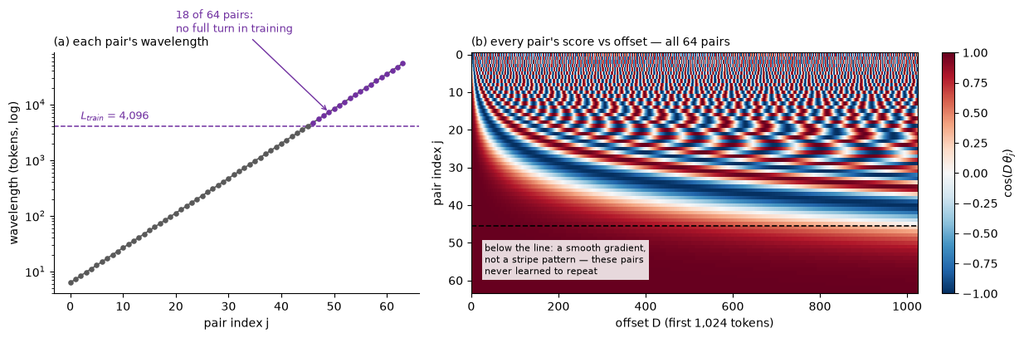

```python
D_HEAD = 128
j = np.arange(D_HEAD // 2)
theta = 10000.0 ** (-2.0 * j / D_HEAD)
wavelength = 2 * np.pi / theta
never = int((wavelength > L_TRAIN).sum())
first = int(np.argmax(wavelength > L_TRAIN))
print(f"L_train = {L_TRAIN}: {never} of 64 pairs never completed one turn "
      f"(pairs j >= {first})")

fig, (a1, a2) = plt.subplots(1, 2, figsize=(12.5, 4.2),
                             gridspec_kw={"width_ratios": [1, 1.35]})
a1.semilogy(j, wavelength, color=C_GRAY, lw=1.2)
a1.scatter(j[:first], wavelength[:first], s=14, color=C_GRAY, zorder=3)
a1.scatter(j[first:], wavelength[first:], s=14, color=C_PURPLE, zorder=3)
a1.axhline(L_TRAIN, color=C_PURPLE, ls="--", lw=1.1)
a1.text(2, L_TRAIN * 1.3, f"$L_{{train}}$ = {L_TRAIN:,}", fontsize=9, color=C_PURPLE)
a1.annotate(f"{never} of 64 pairs:\nno full turn in training",
            xy=(first + 3, wavelength[first + 3]), xytext=(20, 2e5),
            fontsize=9, color=C_PURPLE,
            arrowprops=dict(arrowstyle="->", color=C_PURPLE, lw=1))
a1.set_xlabel("pair index j"), a1.set_ylabel("wavelength (tokens, log)")
a1.set_title("(a) each pair's wavelength", fontsize=10, loc="left")
a1.spines[["top", "right"]].set_visible(False)

DW = 1024
grid = np.cos(np.arange(DW)[None, :] * theta[:, None])
im = a2.imshow(grid, aspect="auto", cmap="RdBu_r", vmin=-1, vmax=1,
               interpolation="nearest", extent=(0, DW, 63.5, -0.5))
a2.axhline(first - 0.5, color="black", ls="--", lw=1.2)
a2.text(DW * 0.03, first + 4, "below the line: a smooth gradient,\nnot a stripe "
        "pattern — these pairs\nnever learned to repeat", fontsize=8, va="top",
        bbox=dict(fc="white", ec="none", alpha=0.85, pad=2))
a2.set_xlabel(f"offset D (first {DW:,} tokens)"), a2.set_ylabel("pair index j")
a2.set_title("(b) every pair's score vs offset — all 64 pairs",
             fontsize=10, loc="left")
plt.colorbar(im, ax=a2, fraction=0.046, label=r"$\cos(D\,\theta_j)$")
plt.tight_layout(); plt.show()
```

## What H1L1 showed

[output not shown]

**Next (H2L1):** the angles are no longer set by hand; gradient descent chooses them.